# Applied Bayes in R

Pavel Jakubec

September, 2016

# Bayes application in R

## 1. Introduction

### 1.2 Why Bayiesian methods?

Easier to understand  
Easier to communicate  
[No p-values](https://www.amstat.org/newsroom/pressreleases/P-ValueStatement.pdf)

# $P(\theta \mid y)=\frac{P(\theta )P(y\mid \theta ))}{P(y)}$

$\theta$ = Model parameter  
y = Actual data

$posterior.distribution=\frac{Prior.for.(\theta )Probability.of.data.given.the.(\theta )}{Prior.probability.of.data}$

The equation solves the problem of updating prior information about parameters by actually observed data to obtain posterior knowledge.

Solves everyday questions like probability of rain or which theory is more likely to explain observed phenomenon (brest cancer, marble problem).

EXPLAIN!:

Credible interval (CrI) = Interval in which we expect the true parameter lies with probability of 0.95 (The symmetric 95% CrI is the interval between the 2.5% and 97.5%)

(rewrite in my words) Marginal probability: the probability of an event occurring (p(A)), it may be thought of as an unconditional probability. It is not conditioned on another event. Example: the probability that a card drawn is red (p(red) = 0.5). Another example: the probability that a card drawn is a 4 (p(four)=1/13).

(rewrite in my words) Joint probability: p(A and B). The probability of event A and event B occurring. It is the probability of the intersection of two or more events. The probability of the intersection of A and B may be written p(A ∩ B). Example: the probability that a card is a four and red =p(four and red) = 2/52=1/26. (There are two red fours in a deck of 52, the 4 of hearts and the 4 of diamonds).

(rewrite in my words) Conditional probability: p(A|B) is the probability of event A occurring, given that event B occurs. Example: given that you drew a red card, what’s the probability that it’s a four (p(four|red))=2/26=1/13. So out of the 26 red cards (given a red card), there are two fours so 2/26=1/13.

### Bayesians are (more or less) ok with:

Using prior knowledge  
Low sample size (rare species, lots of NAs, expensive sampling)  
Multiple comparisons [(Geldman et al., 2012)](http://www.stat.columbia.edu/~gelman/research/published/multiple2f.pdf)

### Upside

More meaningful inferences (only exact way how to draw inferences for generalized mixed models (Bolker et al., 2008))

### Downside

Choosing a prior  
Priors can disproportionaly influence the posterior  
Computation heavy (less problem now)  
Garbage in = Garbage out

### Exaggerated Example:

We screened Amur Leopard (*Panthera pardus orientalis*) for presence of dangerous blood parasite. If the true percentage of infected ones is greater then 10% we have to inform autorities and take measures to treat them.

```r
data <- data          #Hidden data
N <- c(5,10,15,20,40) #Sample size
sub <- list()         #List for storing data values with different N
tests.freq <- list()  #list for storing results of exact binomial test
tests.bayes <- list() #list for storing results of bayesian version of exact binomial test
for (i in 1:5) {
  sub[[i]] <- data[1:N[i]]
  tests.freq[[i]] <- stats::binom.test (c(length(sub[[i]][sub[[i]]=="1"]), length(sub[[i]][sub[[i]]=="0"])), p=0.1, alternative="greater")
  tests.bayes[[i]] <- BayesianFirstAid::bayes.binom.test(c(length(sub[[i]][sub[[i]]=="1"]), length(sub[[i]][sub[[i]]=="0"])), p=0.1, n.iter = 150000)
}
tests.freq
```

```
## [[1]]
##
##  Exact binomial test
##
## data:  c(length(sub[[i]][sub[[i]] == "1"]), length(sub[[i]][sub[[i]] ==     "0"]))
## number of successes = 1, number of trials = 5, p-value = 0.4095
## alternative hypothesis: true probability of success is greater than 0.1
## 95 percent confidence interval:
##  0.01020622 1.00000000
## sample estimates:
## probability of success
##                    0.2
##
##
## [[2]]
##
##  Exact binomial test
##
## data:  c(length(sub[[i]][sub[[i]] == "1"]), length(sub[[i]][sub[[i]] ==     "0"]))
## number of successes = 2, number of trials = 10, p-value = 0.2639
## alternative hypothesis: true probability of success is greater than 0.1
## 95 percent confidence interval:
##  0.03677144 1.00000000
## sample estimates:
## probability of success
##                    0.2
##
##
## [[3]]
##
##  Exact binomial test
##
## data:  c(length(sub[[i]][sub[[i]] == "1"]), length(sub[[i]][sub[[i]] ==     "0"]))
## number of successes = 3, number of trials = 15, p-value = 0.1841
## alternative hypothesis: true probability of success is greater than 0.1
## 95 percent confidence interval:
##  0.05684687 1.00000000
## sample estimates:
## probability of success
##                    0.2
```

[output cut: 13 more lines]

```
##                    0.2
##
##
## [[5]]
##
##  Exact binomial test
##
## data:  c(length(sub[[i]][sub[[i]] == "1"]), length(sub[[i]][sub[[i]] ==     "0"]))
## number of successes = 8, number of trials = 40, p-value = 0.0419
## alternative hypothesis: true probability of success is greater than 0.1
## 95 percent confidence interval:
##  0.1036061 1.0000000
## sample estimates:
## probability of success
##                    0.2
```

```r
tests.bayes
```

```
## [[1]]
##
##  Bayesian First Aid binomial test
##
## data: c(length(sub[[i]][sub[[i]] == "1"]), length(sub[[i]][sub[[i]] ==     "0"]))
## number of successes = 1, number of trials = 5
## Estimated relative frequency of success:
##   0.26
## 95% credible interval:
##   0.022 0.59
## The relative frequency of success is more than 0.1 by a probability of 0.886
## and less than 0.1 by a probability of 0.114
##
##
## [[2]]
##
##  Bayesian First Aid binomial test
##
## data: c(length(sub[[i]][sub[[i]] == "1"]), length(sub[[i]][sub[[i]] ==     "0"]))
## number of successes = 2, number of trials = 10
## Estimated relative frequency of success:
##   0.24
## 95% credible interval:
##   0.043 0.48
## The relative frequency of success is more than 0.1 by a probability of 0.911
## and less than 0.1 by a probability of 0.089
##
##
## [[3]]
##
##  Bayesian First Aid binomial test
##
## data: c(length(sub[[i]][sub[[i]] == "1"]), length(sub[[i]][sub[[i]] ==     "0"]))
## number of successes = 3, number of trials = 15
## Estimated relative frequency of success:
##   0.22
## 95% credible interval:
##   0.057 0.43
## The relative frequency of success is more than 0.1 by a probability of 0.932
## and less than 0.1 by a probability of 0.068
```

[output cut: 13 more lines]

```
## and less than 0.1 by a probability of 0.052
##
##
## [[5]]
##
##  Bayesian First Aid binomial test
##
## data: c(length(sub[[i]][sub[[i]] == "1"]), length(sub[[i]][sub[[i]] ==     "0"]))
## number of successes = 8, number of trials = 40
## Estimated relative frequency of success:
##   0.21
## 95% credible interval:
##   0.098 0.34
## The relative frequency of success is more than 0.1 by a probability of 0.982
## and less than 0.1 by a probability of 0.018
```

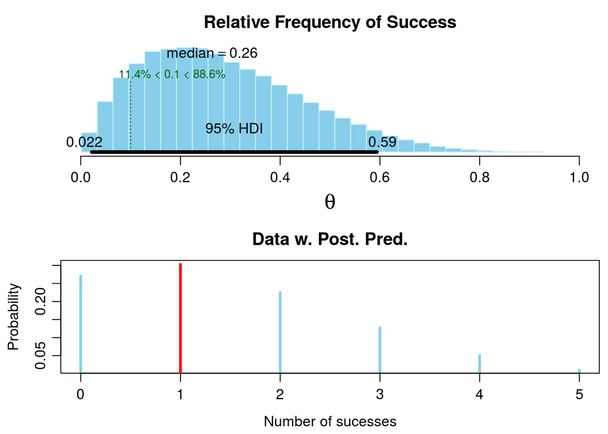

```r
plot (tests.bayes[[1]])
```

```r
summary(tests.bayes[[1]])
```

```
##   Data
## number of successes = 1, number of trials = 5
##
##   Model parameters and generated quantities
## theta: the relative frequency of success
## x_pred: predicted number of successes in a replication
##
##   Measures
##         mean    sd HDIlo HDIup %<comp %>comp
## theta  0.286 0.160 0.022 0.594  0.114  0.886
## x_pred 1.427 1.236 0.000 4.000  0.273  0.727
##
## 'HDIlo' and 'HDIup' are the limits of a 95% HDI credible interval.
## '%<comp' and '%>comp' are the probabilities of the respective parameter being
## smaller or larger than 0.1.
##
##   Quantiles
##        q2.5%  q25% median q75% q97.5%
## theta  0.044 0.161  0.264 0.39  0.641
## x_pred 0.000 0.000  1.000 2.00  4.000
```

```r
diagnostics(tests.bayes[[1]])
```

```
##
## Iterations = 1:50000
## Thinning interval = 1
## Number of chains = 3
## Sample size per chain = 50000
##
##   Diagnostic measures
##         mean    sd mcmc_se  n_eff Rhat
## theta  0.286 0.160   0.000 149999    1
## x_pred 1.427 1.236   0.003 149025    1
##
## mcmc_se: the estimated standard error of the MCMC approximation of the mean.
## n_eff: a crude measure of effective MCMC sample size.
## Rhat: the potential scale reduction factor (at convergence, Rhat=1).
##
##   Model parameters and generated quantities
## theta: The relative frequency of success
## x_pred: Predicted number of successes in a replication
```

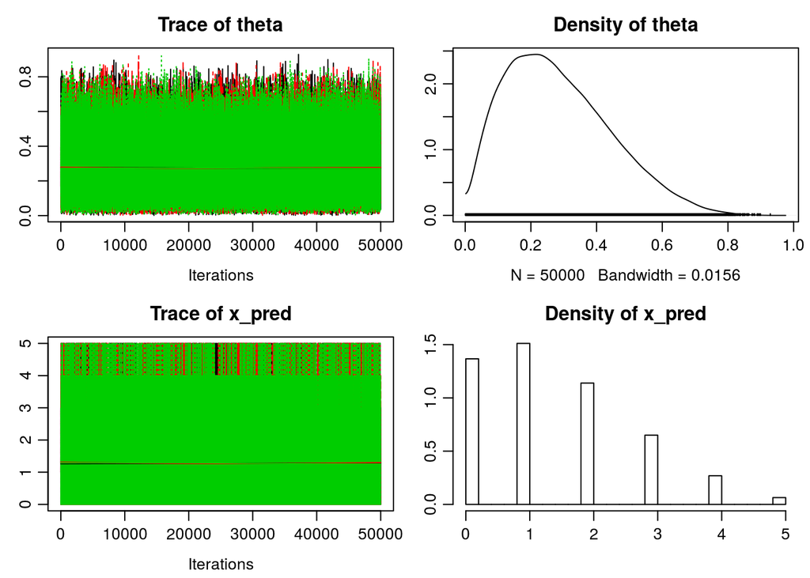

```r
data
```

```
##  [1] 0 0 0 0 1 0 0 0 0 1 0 0 0 0 1 0 0 0 0 1 0 0 0 0 1 0 0 0 0 1 0 0 0 0 1
## [36] 0 0 0 0 1
```

#### * We would need probably **ALL** Amur Leopards in the World to barely reject frequntist’s H0 and do something to save them.

This is linked to statistical power of the test:

```r
h<-ES.h(0.2,0.1) #true proportion is 20% and H0 proportion is 10%
pwr.p.test(h=h, n=40, sig.level=0.05, alternative = "greater")
```

```
##
##      proportion power calculation for binomial distribution (arcsine transformation)
##
##               h = 0.2837941
##               n = 40
##       sig.level = 0.05
##           power = 0.5596248
##     alternative = greater
```

#### * If the frequentist’s H0 would be different, the outcome would be also different.

### Why this is not true for bayesian?

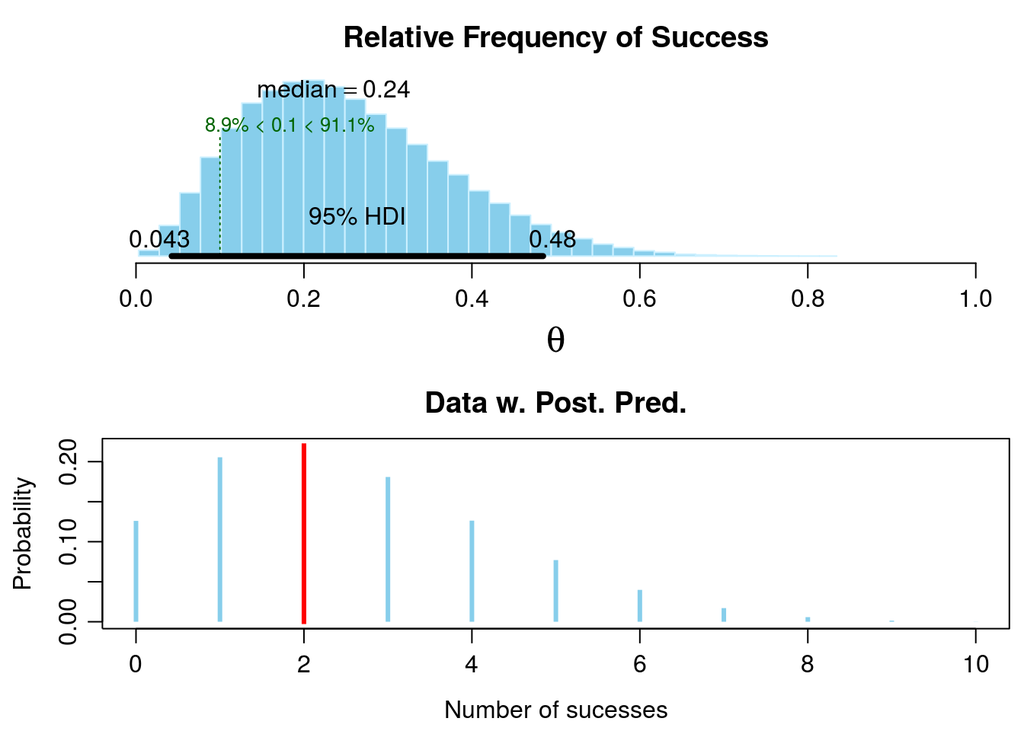

```r
plot(tests.bayes[[2]])
```

## 2. Normal Linear Model